# MBNMAdose for dose-response Model-Based (Network) Meta-Analysis

### Examining the dose-response relationship

In order to consider which functional forms may be appropriate for modelling the dose-response relationship, it is useful to look at results from a “split” network meta-analysis (NMA), in which each dose of an agent is considered as separate and unrelated (i.e. we are not assuming any dose-response relationship). The `nma.run()` function performs a simple NMA, and by default it drops studies that are disconnected at the treatment-level (since estimates for these will be very uncertain if included).

```r
# Run a random effect split NMA using the alogliptin dataset
alognet <- mbnma.network(alog_pcfb)
nma.alog <- nma.run(alognet, method="random")
```

```r
print(nma.alog)
```

```
#> $jagsresult
#> Inference for Bugs model at "C:\Users\hp17602\AppData\Local\Temp\RtmpmeY2V3\file5fac733c5b38", fit using jags,
#>  3 chains, each with 10000 iterations (first 5000 discarded), n.thin = 5
#>  n.sims = 3000 iterations saved
#>            mu.vect sd.vect     2.5%      25%      50%      75%    97.5%
#> d[1]         0.000   0.000    0.000    0.000    0.000    0.000    0.000
#> d[2]        -0.457   0.092   -0.638   -0.518   -0.459   -0.397   -0.270
#> d[3]        -0.655   0.046   -0.747   -0.685   -0.656   -0.628   -0.559
#> d[4]        -0.711   0.046   -0.796   -0.742   -0.713   -0.682   -0.615
#> d[5]        -0.759   0.085   -0.923   -0.815   -0.760   -0.705   -0.585
#> d[6]        -0.679   0.172   -1.012   -0.792   -0.681   -0.566   -0.339
#> sd           0.123   0.028    0.076    0.104    0.121    0.141    0.180
#> totresdev   47.316   9.846   30.329   40.318   46.538   53.759   68.674
#> deviance  -123.999   9.846 -140.985 -130.996 -124.776 -117.555 -102.640
#>            Rhat n.eff
#> d[1]      1.000     1
#> d[2]      1.002  1800
#> d[3]      1.001  3000
#> d[4]      1.001  3000
#> d[5]      1.001  3000
#> d[6]      1.001  2800
#> sd        1.003   890
#> totresdev 1.002  1600
#> deviance  1.002  1700
#>
#> For each parameter, n.eff is a crude measure of effective sample size,
#> and Rhat is the potential scale reduction factor (at convergence, Rhat=1).
#>
#> DIC info (using the rule, pD = var(deviance)/2)
#> pD = 48.4 and DIC = -75.6
#> DIC is an estimate of expected predictive error (lower deviance is better).
#>
#> $trt.labs
#> [1] "Placebo_0"       "alogliptin_6.25" "alogliptin_12.5" "alogliptin_25"
#> [5] "alogliptin_50"   "alogliptin_100"
#>
#> attr(,"class")
#> [1] "nma"
```

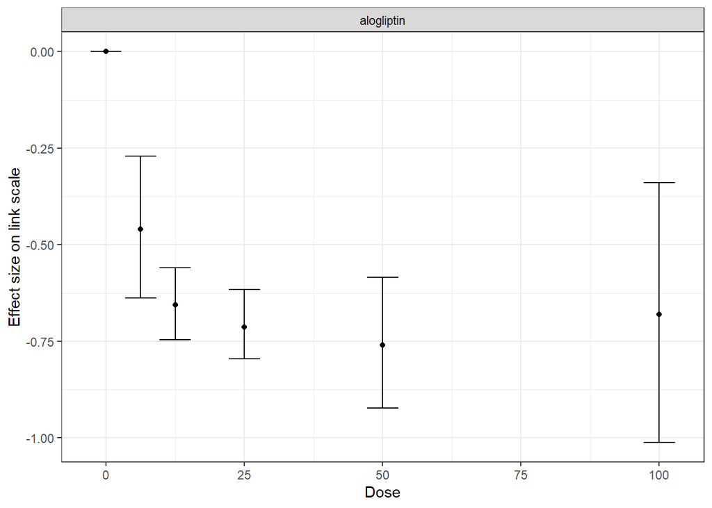

```r
# Draw plot of NMA estimates plotted by dose
plot(nma.alog)
```

In the alogliptin dataset there appears to be a dose-response relationship, and it also appears to be non-linear.

One additional use of `nma.run()` is that is can be used after fitting an MBNMA to ensure that fitting a dose-response function is not leading to poorer model fit than when conducting a conventional NMA. Comparing the total residual deviance between NMA and MBNMA models is useful to identify if introducing a dose-response relationship is leading to poorer model fit. However, it is important to note that if treatments are disconnected in the NMA and have been dropped (`drop.discon=TRUE`), there will be fewer observations present in the dataset, which will subsequently lead to lower pD and lower residual deviance, meaning that model fit statistics from NMA and MBNMA may not be directly comparable.

## Analysis using `mbnma.run()`

MBNMA is performed in `MBNMAdose` by applying `mbnma.run()`. A `"mbnma.network"` object must be provided as the data for `mbnma.run()`. The key arguments within `mbnma.run()` involve specifying the functional form used to model the dose-response, and the dose-response parameters that comprise that functional form.

#### Dose-response functions

Several different functional forms are implemented within `MBNMAdose`, that allow a variety of parameterizations and dose-response shapes. These are provided to the `fun` argument in `mbnma.run()`:

- `"linear"`
- `"exponential"`
- `"emax"` - Emax without a Hill parameter
- `"emax.hill"` - Emax with a Hill parameter
- `"nonparam.up"` - Non-parametric monotonically increasing dose-response
- `"nonparam.down"` - Non-parametric monotonically decreasing dose-response
- `"user"` - A function that can be explicitly specified by the user within `user.fun` (see `?mbnma.run()`)

#### Dose-response parameters

In `mbnma.run()` it is possible to specify up to four different dose-response parameters, depending on the dose-response function used. These are named `beta.1`, `beta.2`, `beta.3` and `beta.4`, and their interpretation varies depending on the dose-response function used (see `?mbnma.run()`).

For simplification and interpretability, both in the way in which dose-response parameters are defined in the model and in how they are reported in the output, wrapper functions are provided for each of the commonly used dose-response functions in `mbnma.run()`. For example, `mbnma.emax()` is equivalent to `mbnma.run(fun="emax")`, but with a different naming of dose-response parameters (`emax` instead of `beta.1` and `ed50` instead of `beta.2`). Several of these wrapper functions will be shown in other examples in this vignette.

In `mbnma.run()`, an additional argument, `method`, indicates what method to use for pooling relative effects and can take either the values `"common"`, implying that all studies estimate the same true effect (akin to a “fixed effect” meta-analysis), or `"random"`, implying that all studies estimate a separate true effect, but that each of these true effects vary randomly around a true mean effect. This approach allows for modelling of between-study heterogeneity.

If relative effects (`"rel"`) are modelled on more than one dose-response parameter then by default, a correlation will be assumed between the dose-response parameters, which will typically improve estimation (provided the parameters are correlated…they usually are). This can be prevented by setting `cor=FALSE`.

### Output

`mbnma.run()` returns an object of class `c("rjags", "mbnma")`. `summary()` provides posterior medians and 95% credible intervals (95%CrI) for different parameters in the model, naming them by agent and giving some explanation of the way they have been specified in the model. `print()` can also be used to give full summary statistics of the posterior distributions for monitored nodes in the JAGS model. Estimates are automatically reported for parameters of interest depending on the model specification (unless otherwise specified in `parameters.to.save`)

Nodes that are automatically monitored (if present in the model) have the following interpretation. They will have an additional suffix that relates to the name/number of the dose-response parameter to which they correspond (e.g. `d.et50` or `beta.1`):

Model fit statistics for `pD` (effective number of parameters) and `DIC` (Deviance Information Criterion) are also reported, with an explanation as to how they have been calculated.

#### Examples

An example MBNMA of the triptans dataset using an Emax dose-response function and common treatment effects that pool relative effects on both Emax and ED50 parameters follows:

```r
# Run an Emax dose-response MBNMA
mbnma <- mbnma.run(tripnet, fun="emax",
                   beta.1="rel", beta.2="rel", method="common")
```

```
#> `likelihood` not given by user - set to `binomial` based on data provided
#> `link` not given by user - set to `logit` based on assigned value for `likelihood`
```

```r
summary(mbnma)
```

```
#> ========================================
#> Dose-response MBNMA
#> ========================================
#>
#> Dose-response function: emax
#>
#> #### Pooling method ####
#>
#> Method: Common (fixed) effects estimated for relative effects
#>
#>
#>
#>
#> #### beta.1 (emax, emax) dose-response parameter results ####
#>
#> Pooling: relative effects
#>
#>              Parameter   Median      2.5%    97.5%
#> eletriptan      d.1[2] 2.525724 2.2072390 2.925392
#> sumatriptan     d.1[3] 1.765450 1.5315929 2.078287
#> frovatriptan    d.1[4] 1.876473 1.3033333 2.808559
#> almotriptan     d.1[5] 1.882989 1.3821750 3.036026
#> zolmitriptan    d.1[6] 2.030947 1.5975120 2.636276
#> naratriptan     d.1[7] 1.086469 0.5849259 2.053171
#> rizatriptan     d.1[8] 2.401333 1.8969830 3.863767
#>
#>
#> #### beta.2 (emax, ed50) dose-response parameter results ####
#>
#> Parameter modelled on exponential scale to ensure it takes positive values
#> on the natural scale
#> Pooling: relative effects
#>
#>              Parameter     Median       2.5%      97.5%
#> eletriptan      d.2[2] -0.7301098 -1.1610241 -0.3454343
#> sumatriptan     d.2[3] -0.6423370 -1.2523716 -0.1299253
#> frovatriptan    d.2[4] -0.5053173 -1.4939257  0.3751772
#> almotriptan     d.2[5] -0.1605373 -0.9222512  0.7087968
#> zolmitriptan    d.2[6] -0.4053003 -1.1622814  0.1875720
#> naratriptan     d.2[7] -0.1146393 -1.1463063  1.0178939
#> rizatriptan     d.2[8] -0.5802892 -1.3475718  0.3798335
#>
#>
#>
#>
#> #### Model Fit Statistics ####
#>
#> Effective number of parameters:
#> pD (pV) calculated using the rule, pD = var(deviance)/2 = 79.1
#> Deviance = 1170.4
#> Residual deviance = 267.3
#> Deviance Information Criterion (DIC) = 1249.5
```

```r
# An alternative would be to use an Emax wrapper for mbnma.run() which would give the
#same result but with more easily interpretable parameter names
mbnma.emax(tripnet, emax="rel", ed50="rel", method="common")
```

In this example the `d.1`/`d.emax` parameters are the effects of each agent for the dose-response parameter `beta.1`/`emax`. For an Emax model this corresponds to the maximum response that can be achieved for a particular agent. The `d.2`/`d.ed50` parameters are the effects for each agent for `beta.2`/`ed50`, which (for an Emax function) corresponds to the dose at which 50% of the maximum response is achieved. Results for ED50 are given on the log scale as it is constrained to be greater than zero.

Instead of estimating a separate relative effect for each agent, a simpler dose-response model that makes stronger assumptions could estimate a single parameter across the whole network for ED50, but still estimates a separate effect for each agent for Emax. In this case we can model random relative effects:

```r
# Emax model with single parameter estimated for Emax
emax <- mbnma.emax(tripnet, emax="rel", ed50="common", method="random")
```

```
#> `likelihood` not given by user - set to `binomial` based on data provided
#> `link` not given by user - set to `logit` based on assigned value for `likelihood`
```

```r
summary(emax)
```

```
#> ========================================
#> Dose-response MBNMA
#> ========================================
#>
#> Dose-response function: emax
#>
#> #### Pooling method ####
#>
#> Method: Random effects estimated for relative effects
#>
#> Parameter                    Median (95%CrI)
#> -----------------------------------------------------------------------
#> Between-study SD for relative effects        0.243 (0.161, 0.337)
#>
#>
#> #### emax dose-response parameter results ####
#>
#> Pooling: relative effects
#>
#>              Parameter   Median      2.5%    97.5%
#> eletriptan   d.emax[2] 2.839961 2.3643918 3.454069
#> sumatriptan  d.emax[3] 1.905446 1.6216141 2.300826
#> frovatriptan d.emax[4] 2.136920 1.4920415 3.018302
#> almotriptan  d.emax[5] 1.786849 1.3599660 2.346507
#> zolmitriptan d.emax[6] 2.123947 1.7103030 2.673683
#> naratriptan  d.emax[7] 1.007168 0.4072445 1.675341
#> rizatriptan  d.emax[8] 2.711365 2.2133755 3.471650
#>
#>
#> #### ed50 dose-response parameter results ####
#>
#> Parameter modelled on exponential scale to ensure it takes positive values
#> on the natural scale
#> Pooling: single parameter shared across the network
#>
#>           Parameter     Median       2.5%     97.5%
#> beta.ed50 beta.ed50 -0.3626732 -0.8496658 0.1137168
#>
#>
#>
#>
#> #### Model Fit Statistics ####
#>
#> Effective number of parameters:
#> pD (pV) calculated using the rule, pD = var(deviance)/2 = 186.4
#> Deviance = 1095.2
#> Residual deviance = 192.1
#> Deviance Information Criterion (DIC) = 1281.5
```

In this example the `d.1`/`d.emax` parameters are the effects of each agent for the dose-response parameter `beta.1`/`emax`, as previously. But now there is a `beta.ed50` parameter in the output (instead of `d.ed50`), which is the absolute value of ED50 (on the log scale) across all agents in the network. As we have modelled random relative effects, we also have estimated a parameter for `sd`, the standard deviation for relative effects between studies.

The total residual deviance (`totresdev`) is lower in the second model, indicating a better fit, but the effective number of parameters (pD) is much greater due to the modelling of random effects, and overall the DIC is higher, suggesting that the first model is a better compromise of fit and complexity. Furthermore it makes less strong assumptions regarding the exchangeability of effects on ED50 between agents.